# Optimal Treatment Analysis

## Outcome Variable

**Outcome Variable:** ever_wasted

## Predictor Variables

**Intervention Variable:** impsan

**Adjustment Set:**

- arm
- sex
- W_mage
- meducyrs
- feducyrs
- hhwealth_quart
- hfoodsec
- W_mhtcm
- W_nrooms
- W_nchldlt5
- W_parity
- impfloor
- safeh20
- delta_W_mage
- delta_meducyrs
- delta_feducyrs
- delta_hhwealth_quart
- delta_hfoodsec
- delta_W_mhtcm
- delta_W_nrooms
- delta_W_nchldlt5
- delta_W_parity
- delta_impfloor
- delta_safeh20

## Stratifying Variables

The analysis was stratified on these variable(s):

- agecat
- studyid
- country

## Data Summary

| agecat | studyid | country | impsan | ever_wasted | n_cell | n |
| --- | --- | --- | --- | --- | --- | --- |
| 0-24 months (no birth wast) | ki0047075b-MAL-ED | BANGLADESH | 1 | 0 | 157 | 242 |
| 0-24 months (no birth wast) | ki0047075b-MAL-ED | BANGLADESH | 1 | 1 | 47 | 242 |
| 0-24 months (no birth wast) | ki0047075b-MAL-ED | BANGLADESH | 0 | 0 | 28 | 242 |
| 0-24 months (no birth wast) | ki0047075b-MAL-ED | BANGLADESH | 0 | 1 | 10 | 242 |
| 0-24 months (no birth wast) | ki0047075b-MAL-ED | BRAZIL | 1 | 0 | 193 | 209 |
| 0-24 months (no birth wast) | ki0047075b-MAL-ED | BRAZIL | 1 | 1 | 12 | 209 |
| 0-24 months (no birth wast) | ki0047075b-MAL-ED | BRAZIL | 0 | 0 | 4 | 209 |
| 0-24 months (no birth wast) | ki0047075b-MAL-ED | BRAZIL | 0 | 1 | 0 | 209 |
| 0-24 months (no birth wast) | ki0047075b-MAL-ED | INDIA | 1 | 0 | 75 | 229 |
| 0-24 months (no birth wast) | ki0047075b-MAL-ED | INDIA | 1 | 1 | 30 | 229 |
| 0-24 months (no birth wast) | ki0047075b-MAL-ED | INDIA | 0 | 0 | 69 | 229 |
| 0-24 months (no birth wast) | ki0047075b-MAL-ED | INDIA | 0 | 1 | 55 | 229 |
| 0-24 months (no birth wast) | ki0047075b-MAL-ED | NEPAL | 1 | 0 | 190 | 236 |
| 0-24 months (no birth wast) | ki0047075b-MAL-ED | NEPAL | 1 | 1 | 45 | 236 |
| 0-24 months (no birth wast) | ki0047075b-MAL-ED | NEPAL | 0 | 0 | 1 | 236 |
| 0-24 months (no birth wast) | ki0047075b-MAL-ED | NEPAL | 0 | 1 | 0 | 236 |
| 0-24 months (no birth wast) | ki0047075b-MAL-ED | PERU | 1 | 0 | 59 | 263 |
| 0-24 months (no birth wast) | ki0047075b-MAL-ED | PERU | 1 | 1 | 6 | 263 |
| 0-24 months (no birth wast) | ki0047075b-MAL-ED | PERU | 0 | 0 | 184 | 263 |
| 0-24 months (no birth wast) | ki0047075b-MAL-ED | PERU | 0 | 1 | 14 | 263 |
| 0-24 months (no birth wast) | ki0047075b-MAL-ED | SOUTH AFRICA | 1 | 0 | 3 | 250 |
| 0-24 months (no birth wast) | ki0047075b-MAL-ED | SOUTH AFRICA | 1 | 1 | 1 | 250 |
| 0-24 months (no birth wast) | ki0047075b-MAL-ED | SOUTH AFRICA | 0 | 0 | 204 | 250 |
| 0-24 months (no birth wast) | ki0047075b-MAL-ED | SOUTH AFRICA | 0 | 1 | 42 | 250 |
| 0-24 months (no birth wast) | ki0047075b-MAL-ED | TANZANIA, UNITED REPUBLIC OF | 1 | 0 | 0 | 241 |
| 0-24 months (no birth wast) | ki0047075b-MAL-ED | TANZANIA, UNITED REPUBLIC OF | 1 | 1 | 0 | 241 |
| 0-24 months (no birth wast) | ki0047075b-MAL-ED | TANZANIA, UNITED REPUBLIC OF | 0 | 0 | 212 | 241 |
| 0-24 months (no birth wast) | ki0047075b-MAL-ED | TANZANIA, UNITED REPUBLIC OF | 0 | 1 | 29 | 241 |
| 0-24 months (no birth wast) | ki1017093-NIH-Birth | BANGLADESH | 1 | 0 | 180 | 598 |
| 0-24 months (no birth wast) | ki1017093-NIH-Birth | BANGLADESH | 1 | 1 | 53 | 598 |

[output cut: 174 more lines]

The following strata were considered:

- agecat: 0-24 months (no birth wast), studyid: ki0047075b-MAL-ED, country: BANGLADESH
- agecat: 0-24 months (no birth wast), studyid: ki0047075b-MAL-ED, country: BRAZIL
- agecat: 0-24 months (no birth wast), studyid: ki0047075b-MAL-ED, country: INDIA
- agecat: 0-24 months (no birth wast), studyid: ki0047075b-MAL-ED, country: NEPAL
- agecat: 0-24 months (no birth wast), studyid: ki0047075b-MAL-ED, country: PERU
- agecat: 0-24 months (no birth wast), studyid: ki0047075b-MAL-ED, country: SOUTH AFRICA
- agecat: 0-24 months (no birth wast), studyid: ki0047075b-MAL-ED, country: TANZANIA, UNITED REPUBLIC OF
- agecat: 0-24 months (no birth wast), studyid: ki1017093-NIH-Birth, country: BANGLADESH
- agecat: 0-24 months (no birth wast), studyid: ki1017093b-PROVIDE, country: BANGLADESH
- agecat: 0-24 months (no birth wast), studyid: ki1017093c-NIH-Crypto, country: BANGLADESH
- agecat: 0-24 months (no birth wast), studyid: ki1114097-CONTENT, country: PERU
- agecat: 0-24 months (no birth wast), studyid: ki1135781-COHORTS, country: GUATEMALA
- agecat: 0-24 months (no birth wast), studyid: ki1135781-COHORTS, country: INDIA
- agecat: 0-24 months (no birth wast), studyid: ki1135781-COHORTS, country: PHILIPPINES
- agecat: 0-24 months (no birth wast), studyid: ki1148112-LCNI-5, country: MALAWI
- agecat: 0-24 months (no birth wast), studyid: kiGH5241-JiVitA-3, country: BANGLADESH
- agecat: 0-24 months (no birth wast), studyid: kiGH5241-JiVitA-4, country: BANGLADESH
- agecat: 0-6 months (no birth wast), studyid: ki0047075b-MAL-ED, country: BANGLADESH
- agecat: 0-6 months (no birth wast), studyid: ki0047075b-MAL-ED, country: BRAZIL
- agecat: 0-6 months (no birth wast), studyid: ki0047075b-MAL-ED, country: INDIA
- agecat: 0-6 months (no birth wast), studyid: ki0047075b-MAL-ED, country: NEPAL
- agecat: 0-6 months (no birth wast), studyid: ki0047075b-MAL-ED, country: PERU
- agecat: 0-6 months (no birth wast), studyid: ki0047075b-MAL-ED, country: SOUTH AFRICA
- agecat: 0-6 months (no birth wast), studyid: ki0047075b-MAL-ED, country: TANZANIA, UNITED REPUBLIC OF
- agecat: 0-6 months (no birth wast), studyid: ki1017093-NIH-Birth, country: BANGLADESH
- agecat: 0-6 months (no birth wast), studyid: ki1017093b-PROVIDE, country: BANGLADESH
- agecat: 0-6 months (no birth wast), studyid: ki1017093c-NIH-Crypto, country: BANGLADESH
- agecat: 0-6 months (no birth wast), studyid: ki1114097-CONTENT, country: PERU
- agecat: 0-6 months (no birth wast), studyid: ki1135781-COHORTS, country: GUATEMALA
- agecat: 0-6 months (no birth wast), studyid: ki1135781-COHORTS, country: INDIA
- agecat: 0-6 months (no birth wast), studyid: ki1135781-COHORTS, country: PHILIPPINES
- agecat: 0-6 months (no birth wast), studyid: ki1148112-LCNI-5, country: MALAWI
- agecat: 0-6 months (no birth wast), studyid: kiGH5241-JiVitA-3, country: BANGLADESH
- agecat: 0-6 months (no birth wast), studyid: kiGH5241-JiVitA-4, country: BANGLADESH
- agecat: 6-24 months, studyid: ki0047075b-MAL-ED, country: BANGLADESH
- agecat: 6-24 months, studyid: ki0047075b-MAL-ED, country: BRAZIL
- agecat: 6-24 months, studyid: ki0047075b-MAL-ED, country: INDIA
- agecat: 6-24 months, studyid: ki0047075b-MAL-ED, country: NEPAL
- agecat: 6-24 months, studyid: ki0047075b-MAL-ED, country: PERU
- agecat: 6-24 months, studyid: ki0047075b-MAL-ED, country: SOUTH AFRICA
- agecat: 6-24 months, studyid: ki0047075b-MAL-ED, country: TANZANIA, UNITED REPUBLIC OF
- agecat: 6-24 months, studyid: ki1017093-NIH-Birth, country: BANGLADESH
- agecat: 6-24 months, studyid: ki1017093b-PROVIDE, country: BANGLADESH
- agecat: 6-24 months, studyid: ki1017093c-NIH-Crypto, country: BANGLADESH
- agecat: 6-24 months, studyid: ki1114097-CONTENT, country: PERU
- agecat: 6-24 months, studyid: ki1135781-COHORTS, country: GUATEMALA
- agecat: 6-24 months, studyid: ki1135781-COHORTS, country: INDIA
- agecat: 6-24 months, studyid: ki1135781-COHORTS, country: PHILIPPINES
- agecat: 6-24 months, studyid: ki1148112-LCNI-5, country: MALAWI
- agecat: 6-24 months, studyid: kiGH5241-JiVitA-3, country: BANGLADESH
- agecat: 6-24 months, studyid: kiGH5241-JiVitA-4, country: BANGLADESH

### Dropped Strata

Some strata were dropped due to rare outcomes:

- agecat: 0-24 months (no birth wast), studyid: ki0047075b-MAL-ED, country: BRAZIL
- agecat: 0-24 months (no birth wast), studyid: ki0047075b-MAL-ED, country: NEPAL
- agecat: 0-24 months (no birth wast), studyid: ki0047075b-MAL-ED, country: SOUTH AFRICA
- agecat: 0-24 months (no birth wast), studyid: ki0047075b-MAL-ED, country: TANZANIA, UNITED REPUBLIC OF
- agecat: 0-24 months (no birth wast), studyid: ki1114097-CONTENT, country: PERU
- agecat: 0-24 months (no birth wast), studyid: ki1135781-COHORTS, country: GUATEMALA
- agecat: 0-24 months (no birth wast), studyid: ki1148112-LCNI-5, country: MALAWI
- agecat: 0-6 months (no birth wast), studyid: ki0047075b-MAL-ED, country: BANGLADESH
- agecat: 0-6 months (no birth wast), studyid: ki0047075b-MAL-ED, country: BRAZIL
- agecat: 0-6 months (no birth wast), studyid: ki0047075b-MAL-ED, country: NEPAL
- agecat: 0-6 months (no birth wast), studyid: ki0047075b-MAL-ED, country: PERU
- agecat: 0-6 months (no birth wast), studyid: ki0047075b-MAL-ED, country: SOUTH AFRICA
- agecat: 0-6 months (no birth wast), studyid: ki0047075b-MAL-ED, country: TANZANIA, UNITED REPUBLIC OF
- agecat: 0-6 months (no birth wast), studyid: ki1017093b-PROVIDE, country: BANGLADESH
- agecat: 0-6 months (no birth wast), studyid: ki1017093c-NIH-Crypto, country: BANGLADESH
- agecat: 0-6 months (no birth wast), studyid: ki1114097-CONTENT, country: PERU
- agecat: 0-6 months (no birth wast), studyid: ki1135781-COHORTS, country: GUATEMALA
- agecat: 0-6 months (no birth wast), studyid: ki1148112-LCNI-5, country: MALAWI
- agecat: 6-24 months, studyid: ki0047075b-MAL-ED, country: BRAZIL
- agecat: 6-24 months, studyid: ki0047075b-MAL-ED, country: NEPAL
- agecat: 6-24 months, studyid: ki0047075b-MAL-ED, country: SOUTH AFRICA
- agecat: 6-24 months, studyid: ki0047075b-MAL-ED, country: TANZANIA, UNITED REPUBLIC OF
- agecat: 6-24 months, studyid: ki1114097-CONTENT, country: PERU
- agecat: 6-24 months, studyid: ki1135781-COHORTS, country: GUATEMALA
- agecat: 6-24 months, studyid: ki1148112-LCNI-5, country: MALAWI

## Methods Detail

We’re interested in the causal parameters $E[Y_a]$ for all values of $a \in \mathcal{A}$. These parameters represent the mean outcome if, possibly contrary to fact, we intervened to set all units to have $A=a$. Under the randomization and positivity assumptions, these are identified by the statistical parameters $\psi_a=E_W[E_{Y|A,W}(Y|A=a,W)]$. In addition, we’re interested in the mean of $Y$, $E[Y]$ under no intervention (the observed mean). We will estimate these parameters by using SuperLearner to fit the relevant likelihood factors – $E_{Y|A,W}(Y|A=a,W)$ and $p(A=a|W)$, and then updating our likelihood fit using a joint TMLE.

For unadjusted analyses ($W=\{\}$), initial likelihoods were estimated using Lrnr_glm to estimate the simple $E(Y|A)$ and Lrnr_mean to estimate $p(A)$. For adjusted analyses, a small library containing Lrnr_glmnet, Lrnr_xgboost, and Lrnr_mean was used.

Having estimated these parameters, we will then use the delta method to estimate relative risks and attributable risks relative to a prespecified baseline level of $A$.

# Results Detail

## Results Plots

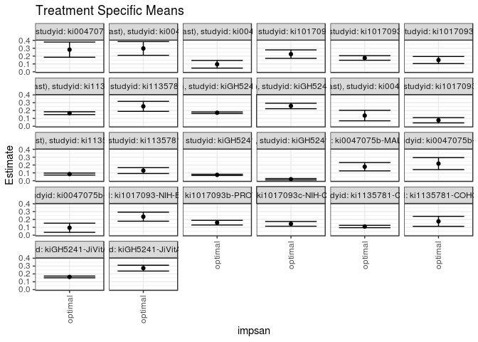

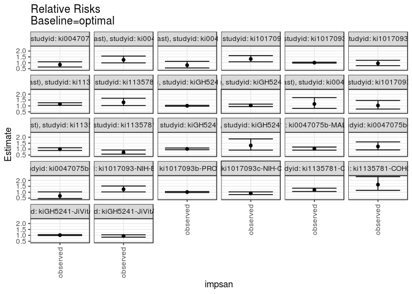

## Results Table

### Parameter: TSM

| agecat | studyid | country | intervention_level | baseline_level | estimate | ci_lower | ci_upper |
| --- | --- | --- | --- | --- | --- | --- | --- |
| 0-24 months (no birth wast) | ki0047075b-MAL-ED | BANGLADESH | optimal | NA | 0.2818539 | 0.1851546 | 0.3785533 |
| 0-24 months (no birth wast) | ki0047075b-MAL-ED | INDIA | optimal | NA | 0.2971089 | 0.2096407 | 0.3845771 |
| 0-24 months (no birth wast) | ki0047075b-MAL-ED | PERU | optimal | NA | 0.0955666 | 0.0468340 | 0.1442993 |
| 0-24 months (no birth wast) | ki1017093-NIH-Birth | BANGLADESH | optimal | NA | 0.2249179 | 0.1710813 | 0.2787545 |
| 0-24 months (no birth wast) | ki1017093b-PROVIDE | BANGLADESH | optimal | NA | 0.1761087 | 0.1468668 | 0.2053506 |
| 0-24 months (no birth wast) | ki1017093c-NIH-Crypto | BANGLADESH | optimal | NA | 0.1495599 | 0.1043770 | 0.1947428 |
| 0-24 months (no birth wast) | ki1135781-COHORTS | INDIA | optimal | NA | 0.1663810 | 0.1483513 | 0.1844107 |
| 0-24 months (no birth wast) | ki1135781-COHORTS | PHILIPPINES | optimal | NA | 0.2534546 | 0.1896336 | 0.3172756 |
| 0-24 months (no birth wast) | kiGH5241-JiVitA-3 | BANGLADESH | optimal | NA | 0.1720324 | 0.1618195 | 0.1822453 |
| 0-24 months (no birth wast) | kiGH5241-JiVitA-4 | BANGLADESH | optimal | NA | 0.2582361 | 0.2234303 | 0.2930418 |
| 0-6 months (no birth wast) | ki0047075b-MAL-ED | INDIA | optimal | NA | 0.1359270 | 0.0691795 | 0.2026746 |
| 0-6 months (no birth wast) | ki1017093-NIH-Birth | BANGLADESH | optimal | NA | 0.0764521 | 0.0427139 | 0.1101903 |
| 0-6 months (no birth wast) | ki1135781-COHORTS | INDIA | optimal | NA | 0.0842945 | 0.0716759 | 0.0969132 |
| 0-6 months (no birth wast) | ki1135781-COHORTS | PHILIPPINES | optimal | NA | 0.1288245 | 0.0916373 | 0.1660116 |
| 0-6 months (no birth wast) | kiGH5241-JiVitA-3 | BANGLADESH | optimal | NA | 0.0742313 | 0.0666087 | 0.0818539 |
| 0-6 months (no birth wast) | kiGH5241-JiVitA-4 | BANGLADESH | optimal | NA | 0.0186832 | 0.0097860 | 0.0275803 |
| 6-24 months | ki0047075b-MAL-ED | BANGLADESH | optimal | NA | 0.1780115 | 0.1250538 | 0.2309692 |
| 6-24 months | ki0047075b-MAL-ED | INDIA | optimal | NA | 0.2176014 | 0.1415180 | 0.2936848 |
| 6-24 months | ki0047075b-MAL-ED | PERU | optimal | NA | 0.0941016 | 0.0357352 | 0.1524681 |
| 6-24 months | ki1017093-NIH-Birth | BANGLADESH | optimal | NA | 0.2353483 | 0.1775671 | 0.2931295 |
| 6-24 months | ki1017093b-PROVIDE | BANGLADESH | optimal | NA | 0.1592058 | 0.1295040 | 0.1889076 |
| 6-24 months | ki1017093c-NIH-Crypto | BANGLADESH | optimal | NA | 0.1441461 | 0.1138606 | 0.1744317 |
| 6-24 months | ki1135781-COHORTS | INDIA | optimal | NA | 0.1101341 | 0.0950871 | 0.1251810 |
| 6-24 months | ki1135781-COHORTS | PHILIPPINES | optimal | NA | 0.1759554 | 0.1122842 | 0.2396266 |
| 6-24 months | kiGH5241-JiVitA-3 | BANGLADESH | optimal | NA | 0.1614614 | 0.1504457 | 0.1724771 |
| 6-24 months | kiGH5241-JiVitA-4 | BANGLADESH | optimal | NA | 0.2734312 | 0.2364052 | 0.3104572 |

### Parameter: E(Y)

| agecat | studyid | country | intervention_level | baseline_level | estimate | ci_lower | ci_upper |
| --- | --- | --- | --- | --- | --- | --- | --- |
| 0-24 months (no birth wast) | ki0047075b-MAL-ED | BANGLADESH | observed | NA | 0.2355372 | 0.1819640 | 0.2891104 |
| 0-24 months (no birth wast) | ki0047075b-MAL-ED | INDIA | observed | NA | 0.3711790 | 0.3084692 | 0.4338889 |
| 0-24 months (no birth wast) | ki0047075b-MAL-ED | PERU | observed | NA | 0.0760456 | 0.0439490 | 0.1081423 |
| 0-24 months (no birth wast) | ki1017093-NIH-Birth | BANGLADESH | observed | NA | 0.2976589 | 0.2609818 | 0.3343359 |
| 0-24 months (no birth wast) | ki1017093b-PROVIDE | BANGLADESH | observed | NA | 0.1781022 | 0.1494298 | 0.2067746 |
| 0-24 months (no birth wast) | ki1017093c-NIH-Crypto | BANGLADESH | observed | NA | 0.1426649 | 0.1175009 | 0.1678289 |
| 0-24 months (no birth wast) | ki1135781-COHORTS | INDIA | observed | NA | 0.1925912 | 0.1818265 | 0.2033558 |
| 0-24 months (no birth wast) | ki1135781-COHORTS | PHILIPPINES | observed | NA | 0.3301642 | 0.3030549 | 0.3572735 |
| 0-24 months (no birth wast) | kiGH5241-JiVitA-3 | BANGLADESH | observed | NA | 0.1739632 | 0.1661367 | 0.1817897 |
| 0-24 months (no birth wast) | kiGH5241-JiVitA-4 | BANGLADESH | observed | NA | 0.2693935 | 0.2426940 | 0.2960930 |
| 0-6 months (no birth wast) | ki0047075b-MAL-ED | INDIA | observed | NA | 0.1578947 | 0.1104594 | 0.2053301 |
| 0-6 months (no birth wast) | ki1017093-NIH-Birth | BANGLADESH | observed | NA | 0.0793103 | 0.0572998 | 0.1013209 |
| 0-6 months (no birth wast) | ki1135781-COHORTS | INDIA | observed | NA | 0.0835141 | 0.0755270 | 0.0915012 |
| 0-6 months (no birth wast) | ki1135781-COHORTS | PHILIPPINES | observed | NA | 0.0935315 | 0.0766512 | 0.1104118 |
| 0-6 months (no birth wast) | kiGH5241-JiVitA-3 | BANGLADESH | observed | NA | 0.0752554 | 0.0699632 | 0.0805476 |
| 0-6 months (no birth wast) | kiGH5241-JiVitA-4 | BANGLADESH | observed | NA | 0.0243328 | 0.0149179 | 0.0337477 |
| 6-24 months | ki0047075b-MAL-ED | BANGLADESH | observed | NA | 0.1833333 | 0.1342773 | 0.2323893 |
| 6-24 months | ki0047075b-MAL-ED | INDIA | observed | NA | 0.2660944 | 0.2092298 | 0.3229590 |
| 6-24 months | ki0047075b-MAL-ED | PERU | observed | NA | 0.0646388 | 0.0348650 | 0.0944125 |
| 6-24 months | ki1017093-NIH-Birth | BANGLADESH | observed | NA | 0.2939002 | 0.2554778 | 0.3323226 |
| 6-24 months | ki1017093b-PROVIDE | BANGLADESH | observed | NA | 0.1615008 | 0.1323459 | 0.1906557 |
| 6-24 months | ki1017093c-NIH-Crypto | BANGLADESH | observed | NA | 0.1307371 | 0.1060790 | 0.1553953 |
| 6-24 months | ki1135781-COHORTS | INDIA | observed | NA | 0.1315423 | 0.1221962 | 0.1408884 |
| 6-24 months | ki1135781-COHORTS | PHILIPPINES | observed | NA | 0.2884097 | 0.2617831 | 0.3150363 |
| 6-24 months | kiGH5241-JiVitA-3 | BANGLADESH | observed | NA | 0.1648339 | 0.1556475 | 0.1740202 |
| 6-24 months | kiGH5241-JiVitA-4 | BANGLADESH | observed | NA | 0.2573427 | 0.2311603 | 0.2835250 |

### Parameter: RR

| agecat | studyid | country | intervention_level | baseline_level | estimate | ci_lower | ci_upper |
| --- | --- | --- | --- | --- | --- | --- | --- |
| 0-24 months (no birth wast) | ki0047075b-MAL-ED | BANGLADESH | observed | optimal | 0.8356711 | 0.6424269 | 1.0870439 |
| 0-24 months (no birth wast) | ki0047075b-MAL-ED | INDIA | observed | optimal | 1.2493030 | 0.9947602 | 1.5689791 |
| 0-24 months (no birth wast) | ki0047075b-MAL-ED | PERU | observed | optimal | 0.7957342 | 0.5669215 | 1.1168969 |
| 0-24 months (no birth wast) | ki1017093-NIH-Birth | BANGLADESH | observed | optimal | 1.3234111 | 1.0871725 | 1.6109834 |
| 0-24 months (no birth wast) | ki1017093b-PROVIDE | BANGLADESH | observed | optimal | 1.0113195 | 0.9727092 | 1.0514624 |
| 0-24 months (no birth wast) | ki1017093c-NIH-Crypto | BANGLADESH | observed | optimal | 0.9538978 | 0.7527443 | 1.2088049 |
| 0-24 months (no birth wast) | ki1135781-COHORTS | INDIA | observed | optimal | 1.1575309 | 1.0558421 | 1.2690134 |
| 0-24 months (no birth wast) | ki1135781-COHORTS | PHILIPPINES | observed | optimal | 1.3026564 | 1.0290386 | 1.6490283 |
| 0-24 months (no birth wast) | kiGH5241-JiVitA-3 | BANGLADESH | observed | optimal | 1.0112237 | 0.9747751 | 1.0490351 |
| 0-24 months (no birth wast) | kiGH5241-JiVitA-4 | BANGLADESH | observed | optimal | 1.0432064 | 0.9458685 | 1.1505613 |
| 0-6 months (no birth wast) | ki0047075b-MAL-ED | INDIA | observed | optimal | 1.1616140 | 0.7935589 | 1.7003743 |
| 0-6 months (no birth wast) | ki1017093-NIH-Birth | BANGLADESH | observed | optimal | 1.0373859 | 0.7377631 | 1.4586927 |
| 0-6 months (no birth wast) | ki1135781-COHORTS | INDIA | observed | optimal | 0.9907418 | 0.8840500 | 1.1103097 |
| 0-6 months (no birth wast) | ki1135781-COHORTS | PHILIPPINES | observed | optimal | 0.7260380 | 0.5746556 | 0.9172994 |
| 0-6 months (no birth wast) | kiGH5241-JiVitA-3 | BANGLADESH | observed | optimal | 1.0137959 | 0.9408846 | 1.0923574 |
| 0-6 months (no birth wast) | kiGH5241-JiVitA-4 | BANGLADESH | observed | optimal | 1.3023907 | 0.9106509 | 1.8626474 |
| 6-24 months | ki0047075b-MAL-ED | BANGLADESH | observed | optimal | 1.0298961 | 0.9081254 | 1.1679949 |
| 6-24 months | ki0047075b-MAL-ED | INDIA | observed | optimal | 1.2228525 | 0.9298879 | 1.6081167 |
| 6-24 months | ki0047075b-MAL-ED | PERU | observed | optimal | 0.6869041 | 0.4595487 | 1.0267403 |
| 6-24 months | ki1017093-NIH-Birth | BANGLADESH | observed | optimal | 1.2487882 | 1.0221009 | 1.5257515 |
| 6-24 months | ki1017093b-PROVIDE | BANGLADESH | observed | optimal | 1.0144154 | 0.9698520 | 1.0610265 |
| 6-24 months | ki1017093c-NIH-Crypto | BANGLADESH | observed | optimal | 0.9069763 | 0.8020670 | 1.0256075 |
| 6-24 months | ki1135781-COHORTS | INDIA | observed | optimal | 1.1943834 | 1.0631528 | 1.3418125 |
| 6-24 months | ki1135781-COHORTS | PHILIPPINES | observed | optimal | 1.6391072 | 1.1597955 | 2.3165052 |
| 6-24 months | kiGH5241-JiVitA-3 | BANGLADESH | observed | optimal | 1.0208872 | 0.9823087 | 1.0609807 |
| 6-24 months | kiGH5241-JiVitA-4 | BANGLADESH | observed | optimal | 0.9411605 | 0.8468679 | 1.0459519 |

### Parameter: PAR

| agecat | studyid | country | intervention_level | baseline_level | estimate | ci_lower | ci_upper |
| --- | --- | --- | --- | --- | --- | --- | --- |
| 0-24 months (no birth wast) | ki0047075b-MAL-ED | BANGLADESH | optimal | NA | -0.0463167 | -0.1209057 | 0.0282723 |
| 0-24 months (no birth wast) | ki0047075b-MAL-ED | INDIA | optimal | NA | 0.0740701 | 0.0062309 | 0.1419094 |
| 0-24 months (no birth wast) | ki0047075b-MAL-ED | PERU | optimal | NA | -0.0195210 | -0.0520179 | 0.0129759 |
| 0-24 months (no birth wast) | ki1017093-NIH-Birth | BANGLADESH | optimal | NA | 0.0727409 | 0.0282449 | 0.1172369 |
| 0-24 months (no birth wast) | ki1017093b-PROVIDE | BANGLADESH | optimal | NA | 0.0019935 | -0.0048657 | 0.0088526 |
| 0-24 months (no birth wast) | ki1017093c-NIH-Crypto | BANGLADESH | optimal | NA | -0.0068950 | -0.0423955 | 0.0286054 |
| 0-24 months (no birth wast) | ki1135781-COHORTS | INDIA | optimal | NA | 0.0262102 | 0.0108646 | 0.0415557 |
| 0-24 months (no birth wast) | ki1135781-COHORTS | PHILIPPINES | optimal | NA | 0.0767097 | 0.0167925 | 0.1366268 |
| 0-24 months (no birth wast) | kiGH5241-JiVitA-3 | BANGLADESH | optimal | NA | 0.0019308 | -0.0043810 | 0.0082427 |
| 0-24 months (no birth wast) | kiGH5241-JiVitA-4 | BANGLADESH | optimal | NA | 0.0111575 | -0.0142322 | 0.0365471 |
| 0-6 months (no birth wast) | ki0047075b-MAL-ED | INDIA | optimal | NA | 0.0219677 | -0.0300815 | 0.0740169 |
| 0-6 months (no birth wast) | ki1017093-NIH-Birth | BANGLADESH | optimal | NA | 0.0028582 | -0.0232050 | 0.0289215 |
| 0-6 months (no birth wast) | ki1135781-COHORTS | INDIA | optimal | NA | -0.0007804 | -0.0103862 | 0.0088254 |
| 0-6 months (no birth wast) | ki1135781-COHORTS | PHILIPPINES | optimal | NA | -0.0352930 | -0.0657914 | -0.0047946 |
| 0-6 months (no birth wast) | kiGH5241-JiVitA-3 | BANGLADESH | optimal | NA | 0.0010241 | -0.0045165 | 0.0065647 |
| 0-6 months (no birth wast) | kiGH5241-JiVitA-4 | BANGLADESH | optimal | NA | 0.0056496 | -0.0017560 | 0.0130552 |
| 6-24 months | ki0047075b-MAL-ED | BANGLADESH | optimal | NA | 0.0053218 | -0.0171000 | 0.0277437 |
| 6-24 months | ki0047075b-MAL-ED | INDIA | optimal | NA | 0.0484930 | -0.0118598 | 0.1088459 |
| 6-24 months | ki0047075b-MAL-ED | PERU | optimal | NA | -0.0294628 | -0.0700248 | 0.0110991 |
| 6-24 months | ki1017093-NIH-Birth | BANGLADESH | optimal | NA | 0.0585519 | 0.0112346 | 0.1058691 |
| 6-24 months | ki1017093b-PROVIDE | BANGLADESH | optimal | NA | 0.0022950 | -0.0048641 | 0.0094542 |
| 6-24 months | ki1017093c-NIH-Crypto | BANGLADESH | optimal | NA | -0.0134090 | -0.0309509 | 0.0041329 |
| 6-24 months | ki1135781-COHORTS | INDIA | optimal | NA | 0.0214082 | 0.0085062 | 0.0343103 |
| 6-24 months | ki1135781-COHORTS | PHILIPPINES | optimal | NA | 0.1124543 | 0.0511558 | 0.1737529 |
| 6-24 months | kiGH5241-JiVitA-3 | BANGLADESH | optimal | NA | 0.0033725 | -0.0028473 | 0.0095922 |
| 6-24 months | kiGH5241-JiVitA-4 | BANGLADESH | optimal | NA | -0.0160885 | -0.0447594 | 0.0125823 |

### Parameter: PAF

| agecat | studyid | country | intervention_level | baseline_level | estimate | ci_lower | ci_upper |
| --- | --- | --- | --- | --- | --- | --- | --- |
| 0-24 months (no birth wast) | ki0047075b-MAL-ED | BANGLADESH | optimal | NA | -0.1966430 | -0.5565973 | 0.0800739 |
| 0-24 months (no birth wast) | ki0047075b-MAL-ED | INDIA | optimal | NA | 0.1995536 | -0.0052674 | 0.3626429 |
| 0-24 months (no birth wast) | ki0047075b-MAL-ED | PERU | optimal | NA | -0.2567011 | -0.7639126 | 0.1046622 |
| 0-24 months (no birth wast) | ki1017093-NIH-Birth | BANGLADESH | optimal | NA | 0.2443769 | 0.0801828 | 0.3792611 |
| 0-24 months (no birth wast) | ki1017093b-PROVIDE | BANGLADESH | optimal | NA | 0.0111928 | -0.0280564 | 0.0489437 |
| 0-24 months (no birth wast) | ki1017093c-NIH-Crypto | BANGLADESH | optimal | NA | -0.0483303 | -0.3284724 | 0.1727366 |
| 0-24 months (no birth wast) | ki1135781-COHORTS | INDIA | optimal | NA | 0.1360922 | 0.0528887 | 0.2119863 |
| 0-24 months (no birth wast) | ki1135781-COHORTS | PHILIPPINES | optimal | NA | 0.2323379 | 0.0282192 | 0.3935823 |
| 0-24 months (no birth wast) | kiGH5241-JiVitA-3 | BANGLADESH | optimal | NA | 0.0110991 | -0.0258777 | 0.0467430 |
| 0-24 months (no birth wast) | kiGH5241-JiVitA-4 | BANGLADESH | optimal | NA | 0.0414170 | -0.0572295 | 0.1308590 |
| 0-6 months (no birth wast) | ki0047075b-MAL-ED | INDIA | optimal | NA | 0.1391289 | -0.2601459 | 0.4118942 |
| 0-6 months (no birth wast) | ki1017093-NIH-Birth | BANGLADESH | optimal | NA | 0.0360386 | -0.3554487 | 0.3144546 |
| 0-6 months (no birth wast) | ki1135781-COHORTS | INDIA | optimal | NA | -0.0093447 | -0.1311577 | 0.0993504 |
| 0-6 months (no birth wast) | ki1135781-COHORTS | PHILIPPINES | optimal | NA | -0.3773383 | -0.7401728 | -0.0901566 |
| 0-6 months (no birth wast) | kiGH5241-JiVitA-3 | BANGLADESH | optimal | NA | 0.0136082 | -0.0628296 | 0.0845487 |
| 0-6 months (no birth wast) | kiGH5241-JiVitA-4 | BANGLADESH | optimal | NA | 0.2321813 | -0.0981156 | 0.4631297 |
| 6-24 months | ki0047075b-MAL-ED | BANGLADESH | optimal | NA | 0.0290282 | -0.1011695 | 0.1438319 |
| 6-24 months | ki0047075b-MAL-ED | INDIA | optimal | NA | 0.1822399 | -0.0753985 | 0.3781546 |
| 6-24 months | ki0047075b-MAL-ED | PERU | optimal | NA | -0.4558074 | -1.1760479 | 0.0260439 |
| 6-24 months | ki1017093-NIH-Birth | BANGLADESH | optimal | NA | 0.1992237 | 0.0216230 | 0.3445853 |
| 6-24 months | ki1017093b-PROVIDE | BANGLADESH | optimal | NA | 0.0142106 | -0.0310852 | 0.0575165 |
| 6-24 months | ki1017093c-NIH-Crypto | BANGLADESH | optimal | NA | -0.1025647 | -0.2467786 | 0.0249681 |
| 6-24 months | ki1135781-COHORTS | INDIA | optimal | NA | 0.1627479 | 0.0594014 | 0.2547394 |
| 6-24 months | ki1135781-COHORTS | PHILIPPINES | optimal | NA | 0.3899118 | 0.1377791 | 0.5683152 |
| 6-24 months | kiGH5241-JiVitA-3 | BANGLADESH | optimal | NA | 0.0204598 | -0.0180099 | 0.0574758 |
| 6-24 months | kiGH5241-JiVitA-4 | BANGLADESH | optimal | NA | -0.0625180 | -0.1808217 | 0.0439331 |